# 北京市二手房价格预测分析

#### 回归诊断

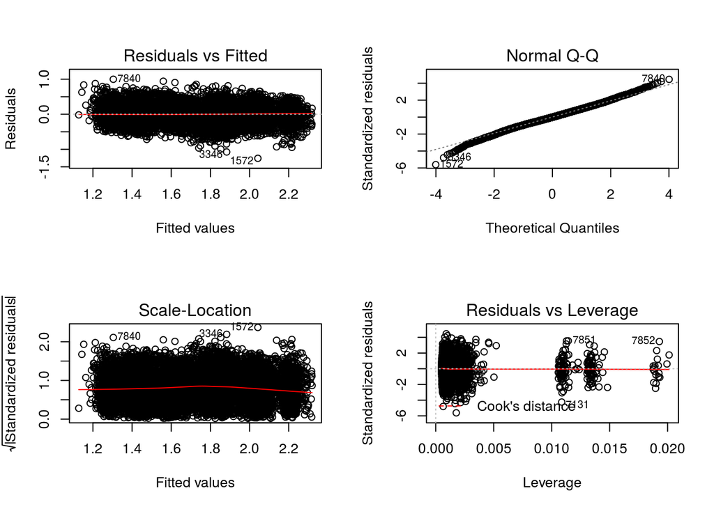

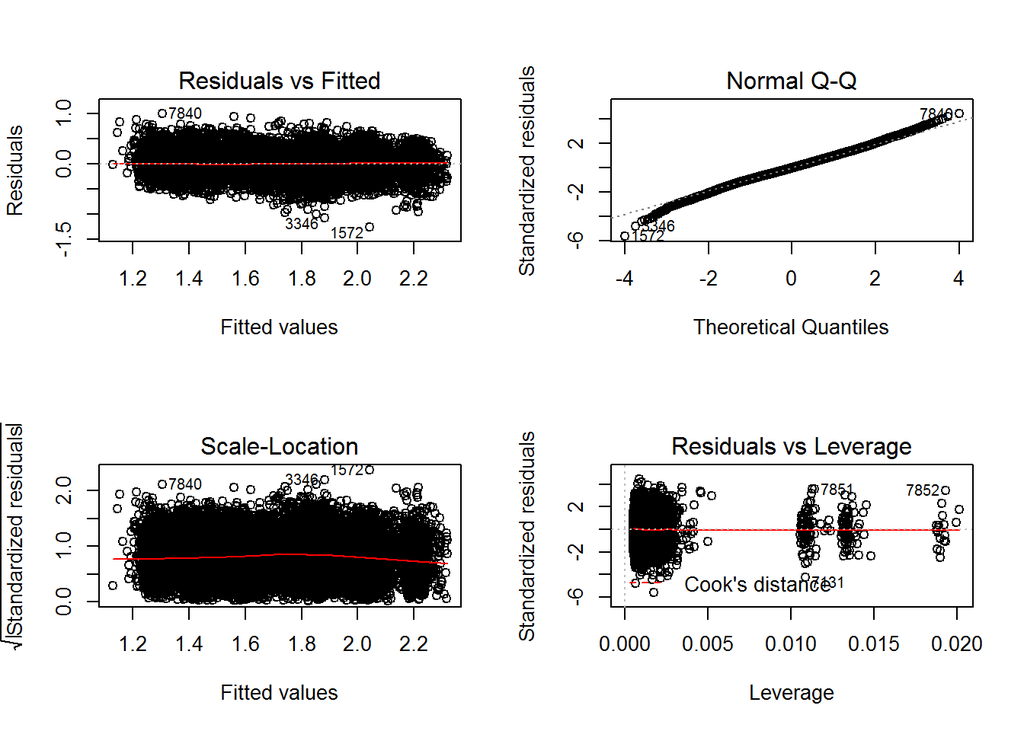

图十

```r
par(mfrow=c(2,2))
plot(lm2.step)
```

### 交互模型

根据前面描述性分析的结果发现，不同的城区、是否为学区房的房价有非常明显的差异。因此，在对数线性模型的基础之上，考虑更为复杂的情况：**城区和学区的交互作用**

```r
lm3.sol <- update(lm2.step, .~.+CATE_dc*school+CATE_ft*school+
                    CATE_hd*school+CATE_sjs*school+CATE_sc*school)
```

#### 回归诊断

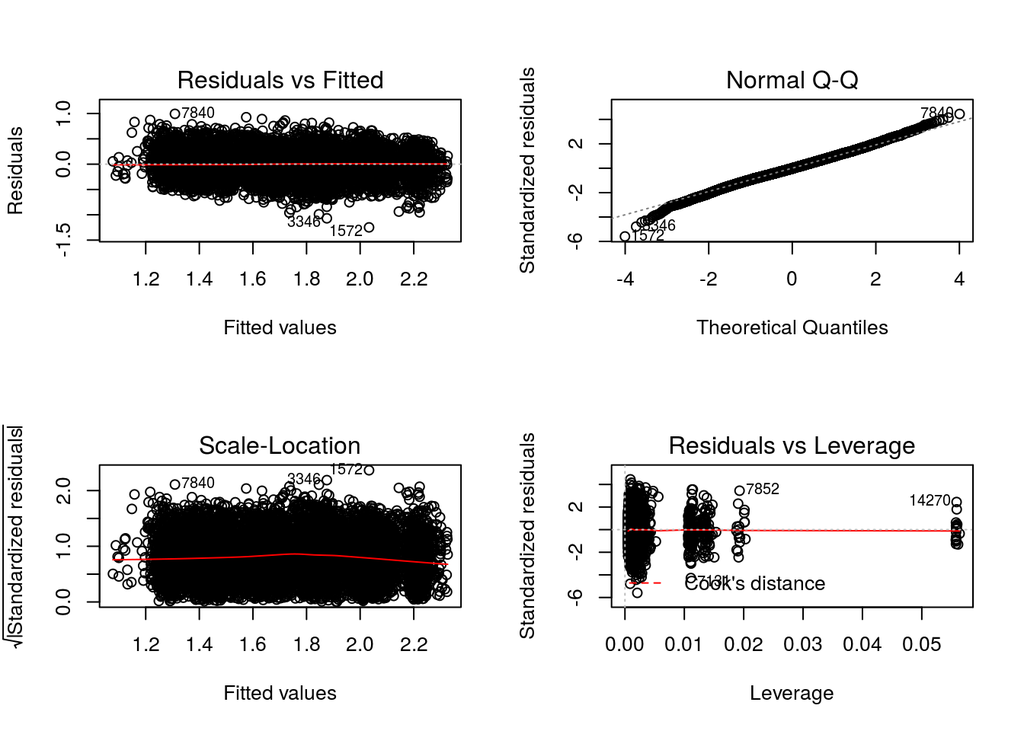

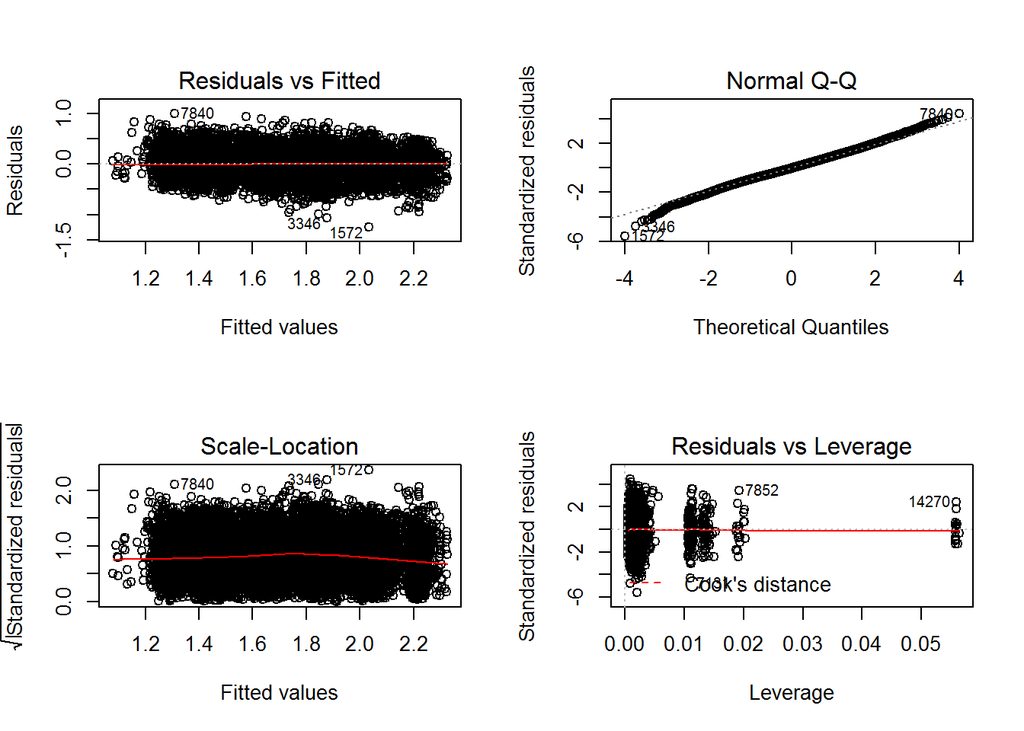

图11

```r
par(mfrow=c(2,2))
plot(lm3.sol)
```